# Exam 1

## Exam 1

#### Question

1. Daniela y Carlos viven en un apartamento y comparten el pago de los gastos. En septiembre consumieron 11 metros cúbicos de gas natural y la factura fue de $15300, incluido el cargo fijo de $3200 que es el mismo todos los meses. La gráfica muestra el consumo histórico en metros cúbicos de ese servicio.

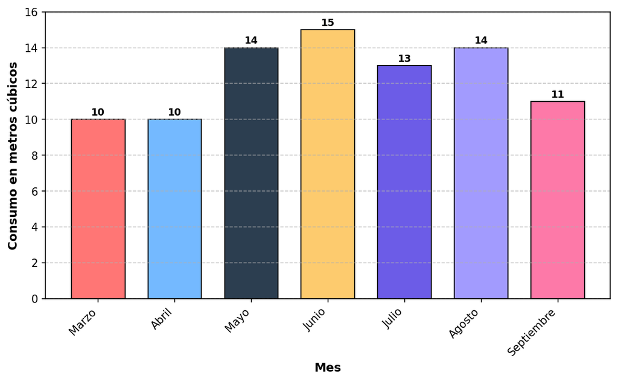

   Un hogar puede consumir máximo 18 metros cúbicos en un mes. Para determinar qué porcentaje del consumo máximo posible corresponde al consumo de mayo, resuelva paso a paso:

   **IMPORTANTE - Formato de números:**
   - **Valores monetarios**: Sin separador de miles, use coma para decimales
     - Ejemplo: $16850,32 (no $16.850,32 ni $16850.32)
     - Significado: dieciséis mil ochocientos cincuenta pesos con treinta y dos centavos
   - **Respuestas numéricas con decimales**: Sin separador de miles, use coma para decimales
     - Ejemplo: 1234,5678 (no 1.234,5678 ni 1234.5678)
     - Significado: mil doscientos treinta y cuatro coma cinco seis siete ocho

### Paso 1: Lectura del gráfico

   Observe cuidadosamente la gráfica de barras. ¿Cuántos metros cúbicos de gas natural se consumieron en mayo?

   **Respuesta:** metros cúbicos

### Paso 2: Identificación del consumo máximo

   Según el enunciado del problema, ¿cuál es el consumo máximo posible que puede tener un hogar en un mes?

   **Respuesta:** metros cúbicos

### Paso 3: Configuración de la fórmula de porcentaje

   Para calcular el porcentaje, complete la fórmula con los valores identificados:

   Porcentaje = ( ÷ ) × 100%

### Paso 4: Cálculo de la división

   Calcule el resultado de la división anterior (exprese su respuesta con 4 decimales):

   ÷ =

   **Ejemplo de formato esperado:** 0,7500 (usando coma decimal)

### Paso 5: Resultado final

   Multiplique el resultado anterior por 100 para obtener el porcentaje final:

   × 100 = %

### Paso 6: Confirmación mediante selección múltiple (CON PUNTUACIÓN)

   Ahora que ha completado el análisis paso a paso, **confirme su respuesta seleccionando la opción correcta**. Esta selección también será evaluada y contribuirá a su puntuación final.

   **Pregunta:** Basándose en su análisis anterior, ¿a qué porcentaje del consumo máximo posible corresponde el consumo de mayo?

   14% / 85% / 78% / 61%

   **Conclusión:** El consumo de mayo representa el % del consumo máximo posible.

### Análisis paso a paso del problema

   Este problema de **interpretación de gráficos de barras** y **cálculo de porcentajes** requiere un análisis secuencial que demuestre el proceso de razonamiento matemático:

   **NOTA IMPORTANTE - Formato de números estandarizado:**
   - **Valores monetarios**: Sin separador de miles, use coma para decimales
     - Ejemplo: $16850,32 (no $16.850,32 ni $16850.32)
   - **Respuestas numéricas con decimales**: Sin separador de miles, coma como separador decimal
     - Ejemplo: 1234,5678 (no 1.234,5678 ni 1234.5678)
   - **Consistencia**: Mismo formato en enunciado, opciones y respuestas

### Paso 1: Lectura correcta de la gráfica ✓

   **Consumos mensuales registrados:**
   - Marzo: 10 metros cúbicos
   - Abril: 10 metros cúbicos
   - Mayo: 14 metros cúbicos ← **MES DE LA PREGUNTA**
   - Junio: 15 metros cúbicos
   - Julio: 13 metros cúbicos
   - Agosto: 14 metros cúbicos
   - Septiembre: 11 metros cúbicos ← **MES DE LA FACTURA**

   **Respuesta correcta:** 14 metros cúbicos

   La lectura cuidadosa del gráfico de barras muestra que en mayo se consumieron exactamente 14 metros cúbicos de gas natural.

### Paso 2: Identificación del consumo máximo ✓

   **Respuesta correcta:** 18 metros cúbicos

   El enunciado establece claramente que “un hogar puede consumir máximo 18 metros cúbicos en un mes”.

### Paso 3: Configuración correcta de la fórmula ✓

   **Respuestas correctas:** Numerador = 14, Denominador = 18

   La fórmula de porcentaje requiere:
   - **Numerador:** El valor observado (14 metros cúbicos)
   - **Denominador:** El valor máximo posible (18 metros cúbicos)

### Paso 4: Cálculo preciso de la división ✓

   **Respuesta correcta:** 0,7778

   $$\frac{14}{18} = 0,7778$$

### Paso 5: Conversión a porcentaje ✓

   **Respuesta correcta:** 78%

   $$0,7778 \times 100 = 78\%$$

### Paso 6: Confirmación mediante selección múltiple ✓ (CON PUNTUACIÓN)

   **Opciones presentadas:**
   - **A**: 14%
   - **B**: 85%
   - **C**: 78% ← **RESPUESTA CORRECTA**
   - **D**: 61%

   **Importancia de este paso:**
   - **Contribuye a la puntuación final** (no es solo verificación)
   - **Confirma** la comprensión del proceso analítico completo
   - **Identifica** posibles errores en el razonamiento matemático
   - **Refuerza** el aprendizaje mediante comparación con distractores educativos

### Verificación del proceso de razonamiento híbrido completo

   **Resultado final:** 78%

   **El formato híbrido con puntuación dual (cloze + schoice) garantiza que los estudiantes:**

   **Parte Analítica (Pasos 1-5):**
   - **Lean cuidadosamente** el gráfico para extraer datos precisos
   - **Identifiquen explícitamente** el consumo máximo del enunciado
   - **Configuren correctamente** la fórmula de porcentaje paso a paso
   - **Realicen cálculos** matemáticos sin saltar etapas del proceso

   **Parte de Confirmación (Paso 6):**
   - **Demuestren coherencia** entre su análisis y la respuesta final
   - **Apliquen pensamiento crítico** al comparar con distractores
   - **Consoliden su aprendizaje** mediante validación de resultados

### Conclusión

   El consumo de mayo (14 metros cúbicos) representa el **78%** del consumo máximo posible (18 metros cúbicos).

   Esta respuesta es coherente porque:
   - Se basa en una lectura correcta de la gráfica
   - Aplica correctamente la fórmula de porcentaje
   - El resultado está dentro del rango esperado (0% a 100%)

   **Verificación adicional**: La factura de septiembre ($15300) corresponde exactamente al consumo mostrado en la gráfica (11 m³ × $1100 + $3200 cargo fijo).

#### Question

2. Andrés y Valentina viven en un apartamento y comparten el pago de los gastos. En julio consumieron 13 metros cúbicos de gas natural y la factura fue de $15050, incluido el cargo fijo de $2700 que es el mismo todos los meses. La gráfica muestra el consumo histórico en metros cúbicos de ese servicio.

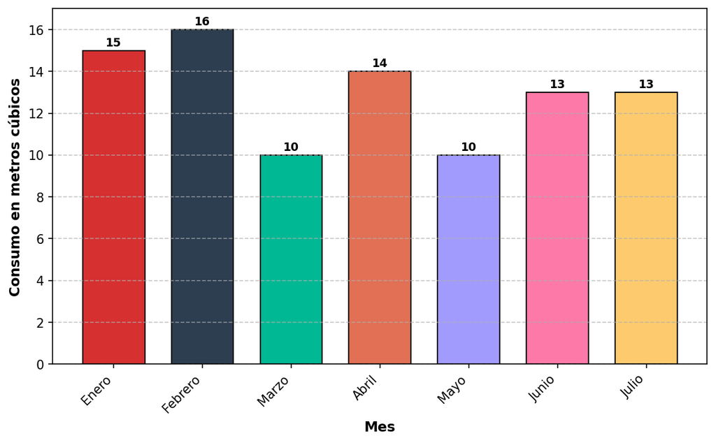

   Un hogar puede consumir máximo 20 metros cúbicos en un mes. Para determinar qué porcentaje del consumo máximo posible corresponde al consumo de febrero, resuelva paso a paso:

   **IMPORTANTE - Formato de números:**
   - **Valores monetarios**: Sin separador de miles, use coma para decimales
     - Ejemplo: $16850,32 (no $16.850,32 ni $16850.32)
     - Significado: dieciséis mil ochocientos cincuenta pesos con treinta y dos centavos
   - **Respuestas numéricas con decimales**: Sin separador de miles, use coma para decimales
     - Ejemplo: 1234,5678 (no 1.234,5678 ni 1234.5678)
     - Significado: mil doscientos treinta y cuatro coma cinco seis siete ocho

### Paso 1: Lectura del gráfico

   Observe cuidadosamente la gráfica de barras. ¿Cuántos metros cúbicos de gas natural se consumieron en febrero?

   **Respuesta:** metros cúbicos

### Paso 2: Identificación del consumo máximo

   Según el enunciado del problema, ¿cuál es el consumo máximo posible que puede tener un hogar en un mes?

   **Respuesta:** metros cúbicos

### Paso 3: Configuración de la fórmula de porcentaje

   Para calcular el porcentaje, complete la fórmula con los valores identificados:

   Porcentaje = ( ÷ ) × 100%

### Paso 4: Cálculo de la división

   Calcule el resultado de la división anterior (exprese su respuesta con 4 decimales):

   ÷ =

   **Ejemplo de formato esperado:** 0,7500 (usando coma decimal)

### Paso 5: Resultado final

   Multiplique el resultado anterior por 100 para obtener el porcentaje final:

   × 100 = %

### Paso 6: Confirmación mediante selección múltiple (CON PUNTUACIÓN)

   Ahora que ha completado el análisis paso a paso, **confirme su respuesta seleccionando la opción correcta**. Esta selección también será evaluada y contribuirá a su puntuación final.

   **Pregunta:** Basándose en su análisis anterior, ¿a qué porcentaje del consumo máximo posible corresponde el consumo de febrero?

   16% / 80% / 65% / 100%

   **Conclusión:** El consumo de febrero representa el % del consumo máximo posible.

### Análisis paso a paso del problema

   Este problema de **interpretación de gráficos de barras** y **cálculo de porcentajes** requiere un análisis secuencial que demuestre el proceso de razonamiento matemático:

   **NOTA IMPORTANTE - Formato de números estandarizado:**
   - **Valores monetarios**: Sin separador de miles, use coma para decimales
     - Ejemplo: $16850,32 (no $16.850,32 ni $16850.32)
   - **Respuestas numéricas con decimales**: Sin separador de miles, coma como separador decimal
     - Ejemplo: 1234,5678 (no 1.234,5678 ni 1234.5678)
   - **Consistencia**: Mismo formato en enunciado, opciones y respuestas

### Paso 1: Lectura correcta de la gráfica ✓

   **Consumos mensuales registrados:**
   - Enero: 15 metros cúbicos
   - Febrero: 16 metros cúbicos ← **MES DE LA PREGUNTA**
   - Marzo: 10 metros cúbicos
   - Abril: 14 metros cúbicos
   - Mayo: 10 metros cúbicos
   - Junio: 13 metros cúbicos
   - Julio: 13 metros cúbicos ← **MES DE LA FACTURA**

   **Respuesta correcta:** 16 metros cúbicos

   La lectura cuidadosa del gráfico de barras muestra que en febrero se consumieron exactamente 16 metros cúbicos de gas natural.

### Paso 2: Identificación del consumo máximo ✓

   **Respuesta correcta:** 20 metros cúbicos

   El enunciado establece claramente que “un hogar puede consumir máximo 20 metros cúbicos en un mes”.

### Paso 3: Configuración correcta de la fórmula ✓

   **Respuestas correctas:** Numerador = 16, Denominador = 20

   La fórmula de porcentaje requiere:
   - **Numerador:** El valor observado (16 metros cúbicos)
   - **Denominador:** El valor máximo posible (20 metros cúbicos)

### Paso 4: Cálculo preciso de la división ✓

   **Respuesta correcta:** 0,8000

   $$\frac{16}{20} = 0,8000$$

### Paso 5: Conversión a porcentaje ✓

   **Respuesta correcta:** 80%

   $$0,8000 \times 100 = 80\%$$

### Paso 6: Confirmación mediante selección múltiple ✓ (CON PUNTUACIÓN)

   **Opciones presentadas:**
   - **A**: 16%
   - **B**: 80% ← **RESPUESTA CORRECTA**
   - **C**: 65%
   - **D**: 100%

   **Importancia de este paso:**
   - **Contribuye a la puntuación final** (no es solo verificación)
   - **Confirma** la comprensión del proceso analítico completo
   - **Identifica** posibles errores en el razonamiento matemático
   - **Refuerza** el aprendizaje mediante comparación con distractores educativos

### Verificación del proceso de razonamiento híbrido completo

   **Resultado final:** 80%

   **El formato híbrido con puntuación dual (cloze + schoice) garantiza que los estudiantes:**

   **Parte Analítica (Pasos 1-5):**
   - **Lean cuidadosamente** el gráfico para extraer datos precisos
   - **Identifiquen explícitamente** el consumo máximo del enunciado
   - **Configuren correctamente** la fórmula de porcentaje paso a paso
   - **Realicen cálculos** matemáticos sin saltar etapas del proceso

   **Parte de Confirmación (Paso 6):**
   - **Demuestren coherencia** entre su análisis y la respuesta final
   - **Apliquen pensamiento crítico** al comparar con distractores
   - **Consoliden su aprendizaje** mediante validación de resultados

### Conclusión

   El consumo de febrero (16 metros cúbicos) representa el **80%** del consumo máximo posible (20 metros cúbicos).

   Esta respuesta es coherente porque:
   - Se basa en una lectura correcta de la gráfica
   - Aplica correctamente la fórmula de porcentaje
   - El resultado está dentro del rango esperado (0% a 100%)

   **Verificación adicional**: La factura de julio ($15050) corresponde exactamente al consumo mostrado en la gráfica (13 m³ × $950 + $2700 cargo fijo).